# DRAFT_MethotrexateAnalysis

Anna Rowan

17/09/2020

## Background

Prescribing high doses of Methotrexate increases the potentially fatal risk of toxicity. To minimise risk, it is recommended that only 2.5mg tablets are prescribed. Evidence Based Medicines Datalab published analysis of trends and variation in unsafe prescribing of methotrexate in primary care in the British Journal of General Practice in July 2020. This paper analysed prescribing in primary care between 2010 and 2018. We now have access to more recent primary care prescribing data (up to June 2020) and secondary care usage data (from January 2019 to June 2020). This note provides an update to the previous analysis.

## Aim

The aim of this note is to describe the prescribing of Methotrexate across primary and secondary care between January 2019 and June 2020 at a national level and understand the variation between Sustainability and Transformation Partnerships (STPs), the lowest level common geographical area shared between CCGs and Trusts.

## Method

The main outcome measures were: total volume of prescribing and the variation in ratio of non-adherent/adherant prescribing geographically, by care setting (primary vs secondary) and over time.

## Gathering data

```r
library(dplyr)
library(tidyverse)
library(reshape)
library(scales)

setwd("C:/Users/User/Documents/GitHub/open-nhs-hospital-use-data/")

# reading in data extracted from bigquery (see code here [to add link])
hospital_data <- read.csv(file = "./data/methotrexate_hospital_data.csv")
community_data <- read.csv(file = "./data/methotrexate_community_data.csv")
# reading in ods data on hospitals - no header information so need to add this in
hospital_to_stp_map <- read.csv(file = "./data/etr.csv", header = FALSE) %>%
  select(1:4)
colnames(hospital_to_stp_map) <- c("ods_code", "trust_name", "region_code", "stp_code")
# reading in map from ccg codes to stp and region codes, published on nhs digital site: https://digital.nhs.uk/data-and-information/publications/statistical/patients-registered-at-a-gp-practice/september-2020
ccg_to_stp_map <- read.csv("./data/gp-reg-pat-prac-map.csv") %>%
  group_by(CCG_CODE) %>%
  summarise(STP_CODE = first(STP_CODE),
            STP_NAME = first(STP_NAME),
            COMM_REGION_NAME = first(COMM_REGION_NAME),
            COMM_REGION_CODE = first(COMM_REGION_CODE))

# merge stp information on to hospital dataset and change variable names so can join with community dataset
hospital_data_with_stp <- left_join(hospital_data, hospital_to_stp_map, by = "ods_code") %>%
  mutate(source = "hospital") %>%
  dplyr::rename(month = year_month,
                stp = stp_code,
                product_name = vmp_product_name,
                quantity = total_quantity) %>%
  group_by(month, stp, source, product_name) %>%
  summarise(quantity = sum(quantity)) %>%
  mutate(COMM_REGION_NAME = NA,
         STP_NAME = NA)

combined_data <- community_data %>%
  mutate(source = "community") %>%
  dplyr::rename(product_name = bnf_name,
                CCG_CODE = pct) %>%
  select(month, CCG_CODE, source, product_name, quantity) %>%
  left_join(., ccg_to_stp_map, by = "CCG_CODE") %>%
  group_by(COMM_REGION_NAME, STP_NAME, STP_CODE, month, source, product_name) %>%
  summarise(quantity = sum(quantity)) %>%
  dplyr::rename(stp = STP_CODE) %>%
  union(., hospital_data_with_stp) %>%
  filter(!is.na(stp)) %>%
  group_by(stp) %>%
  mutate(COMM_REGION_NAME = first(na.omit(COMM_REGION_NAME)),
         STP_NAME = first(na.omit(STP_NAME))) %>%
  ungroup() %>%
  filter(!is.na(STP_NAME))
```

## National prescribing trends

```r
library(dplyr)
# National time series
national_time_series <- combined_data %>%
  group_by(month, source, product_name) %>%
  summarise(nat_quantity = sum(quantity)) %>%
  group_by(month, source) %>%
  mutate(prop_prescribing = nat_quantity / sum(nat_quantity)) %>%
  ungroup()

national_time_series_total <- national_time_series %>%
  group_by(month, source) %>%
  summarise(nat_total_quantity = sum(nat_quantity))
```

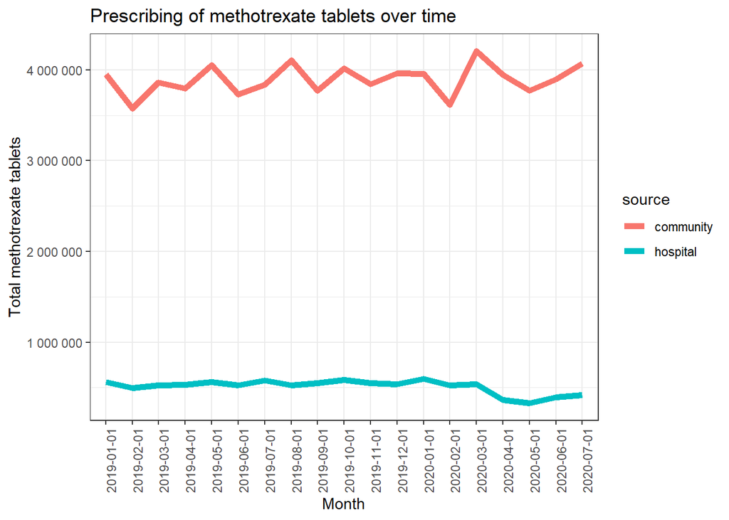

```r
library(ggplot2)
ggplot(national_time_series_total, aes(x = month, y = nat_total_quantity, group = source)) +
  geom_line(aes(color = source), size = 2) +
  labs(x = "Month", y = "Total methotrexate tablets") +
  scale_y_continuous(labels = scales::number) +
  theme_bw() +
  theme(axis.text.x = element_text(angle = 90)) +
  ggtitle("Prescribing of methotrexate tablets over time")
```

```r
library(dplyr)
national_time_series_10mg <- national_time_series %>%
  filter(product_name == "Methotrexate 10mg tablets")
```

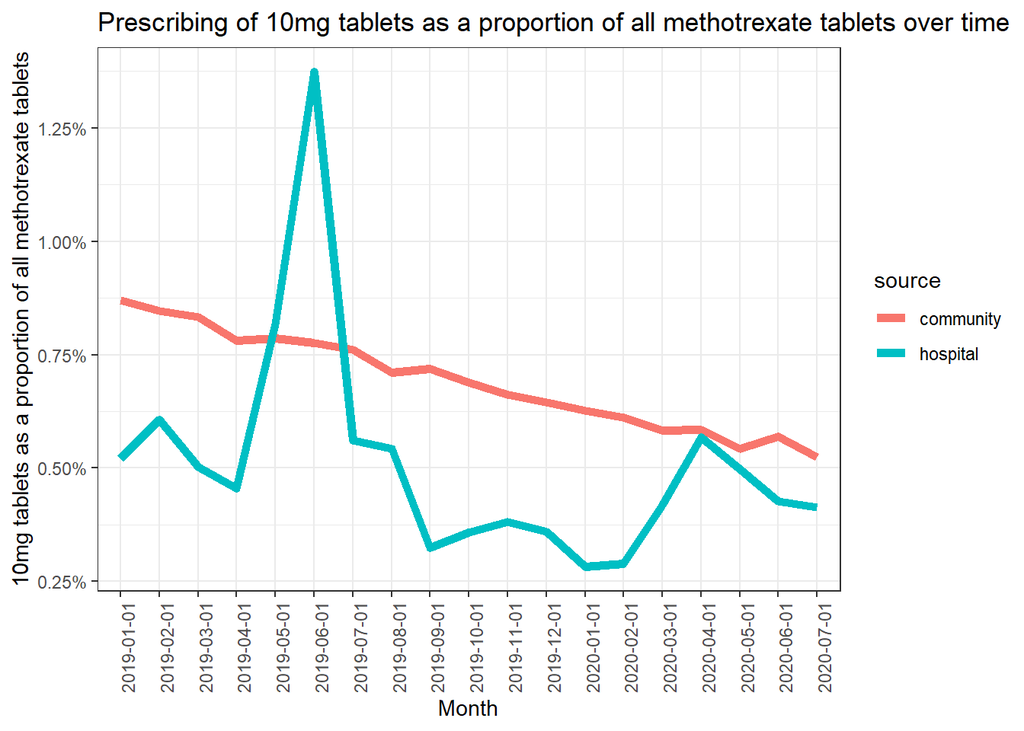

```r
library(ggplot2)
ggplot(national_time_series_10mg, aes(x = month, y = prop_prescribing, group = source)) +
  geom_line(aes(color = source), size = 2) +
  labs(x = "Month", y = "10mg tablets as a proportion of all methotrexate tablets") +
  scale_y_continuous(labels = scales::percent) +
  theme_bw() +
  theme(axis.text.x = element_text(angle = 90)) +
  ggtitle("Prescribing of 10mg tablets as a proportion of all methotrexate tablets over time")
```

## STP prescribing trends

Although prescribing of 10mg methotrexate as a proportion of all methotrexate tablets is low at a national level there is variation across England. Analysis at a STP level allows us to summarise community and hospital prescribing data as STPs are a common geographical level. Figure 3 shows the variation in prescribing of 10mg methotrexate between July 2019 and June 2020 at a STP level.

```r
library(dplyr)
stp_july2019_june2020 <- combined_data %>%
  mutate(month = as.Date(month, "%Y-%m-%d"))%>%
  filter(month >= as.Date("2019-07-01") & month <= as.Date("2020-06-01"))%>%
  group_by(STP_NAME, stp, source, product_name) %>%
  summarise(stp_quantity = sum(quantity)) %>%
  group_by(stp) %>%
  mutate(prop_prescribing = stp_quantity / sum(stp_quantity)) %>%
  ungroup() %>%
  filter(product_name == "Methotrexate 10mg tablets") %>%
  group_by(stp) %>%
  mutate(total = sum(prop_prescribing)) %>%
  ungroup()
```

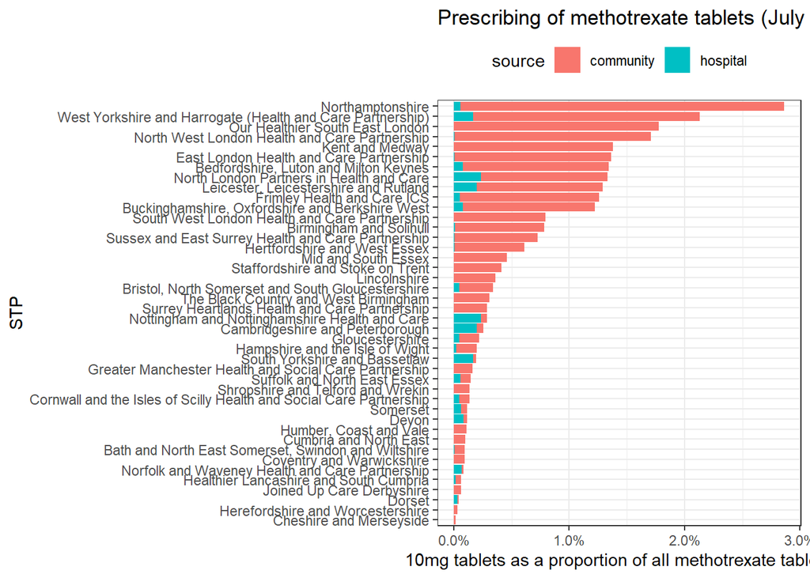

```r
library(ggplot2)
ggplot(stp_july2019_june2020, aes(x = reorder(STP_NAME, total), y = prop_prescribing, fill = source)) +
  geom_bar(position = "stack", stat = "identity") +
  labs(x = "STP", y = "10mg tablets as a proportion of all methotrexate tablets") +
  scale_y_continuous(labels = scales::percent) +
  theme_bw() +
  theme(legend.position = "top") +
  ggtitle("Prescribing of methotrexate tablets (July 2019 to June 2020)") +
  coord_flip()
```

```r
library(DT)
stp_table <- stp_july2019_june2020 %>%
  select(STP_NAME, stp, product_name, source, prop_prescribing) %>%
  cast(., STP_NAME + stp + product_name ~ source, vale = "prop_prescribing") %>%
  mutate(Total = community + hospital) %>%
  arrange(desc(Total))

datatable(stp_table, rownames = FALSE, filter="top", options = list(pageLength = 5, scrollX=T)) %>%
  DT::formatPercentage(c("community", "hospital", "Total"), 2)
```

| STP_NAME | stp | product_name | community | hospital | Total |
| --- | --- | --- | --- | --- | --- |
| Northamptonshire | QPM | Methotrexate 10mg tablets | 0.0280785909162755 | 0.00057589356277446 | 0.02865448447905 |
| West Yorkshire and Harrogate (Health and Care Partnership) | QWO | Methotrexate 10mg tablets | 0.0196376544704395 | 0.00165295466976532 | 0.0212906091402048 |
| North West London Health and Care Partnership | QRV | Methotrexate 10mg tablets | 0.0170272478803562 | 4.60827399369251e-05 | 0.0170733306202932 |
| Kent and Medway | QKS | Methotrexate 10mg tablets | 0.0137788133442669 | 4.71877169324209e-06 | 0.0137835321159601 |
| East London Health and Care Partnership | QMF | Methotrexate 10mg tablets | 0.0135556400369304 | 5.97404008037799e-05 | 0.0136153804377342 |
| Bedfordshire, Luton and Milton Keynes | QHG | Methotrexate 10mg tablets | 0.0126666625610455 | 0.000779657468022343 | 0.0134463200290678 |
| North London Partners in Health and Care | QMJ | Methotrexate 10mg tablets | 0.0109661202056187 | 0.00233499561243736 | 0.0133011158180561 |
| Leicester, Leicestershire and Rutland | QK1 | Methotrexate 10mg tablets | 0.0109128197073315 | 0.00200264699241511 | 0.0129154666997466 |
| Frimley Health and Care ICS | QNQ | Methotrexate 10mg tablets | 0.0120739686529647 | 0.000531384001182907 | 0.0126053526541476 |
| Buckinghamshire, Oxfordshire and Berkshire West | QU9 | Methotrexate 10mg tablets | 0.0114932249828005 | 0.000758205018198018 | 0.0122514300009985 |

[output cut: 32 more lines]